# Calidad del servicio de internet de los estudiantes de UTEC

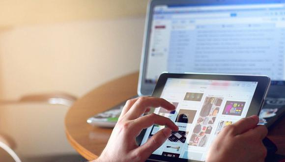

# Introducción

En la actualidad, el internet se ha convertido en un servicio fundamental para la sociedad debido a que permite la comunicación, búsqueda de información y muchas otras actividades que permiten el mejor desempeño de las personas. En este sentido, en la pandemia este servicio se volvió aún más importante puesto que ante la situación muchas actividades se vieron en la necesidad de realizarse de manera virtual por ejemplo las clases en línea. No obstante, en muchos casos, la población no estaba preparada para este cambio puesto que en muchos lugares del mundo la calidad del internet es limitada lo que dificulta su acceso. Es así como, los estudiantes se vieron perjudicados ya que realmente no conocen la calidad de su internet y si este es lo suficientemente bueno para poder desempeñar sus actividades sin problemas. De este modo, con este el presente estudio busca identificar el grado de calidad del internet de los estudiantes y evaluar posibles soluciones que permitan conocer la mejor alternativa de internet para los estudiantes de acuerdo con su contexto actual.

### Población

El internet, al ser una herramienta de carácter cotidiano y laboral, se ha vuelto indispensable en el día a día de la mayor parte de la población peruana. Una fracción de esta, se encuentra ejerciendo sus estudios superiores. No obstante, muchos de estos estudiantes, no gozan de la misma calidad de los servicios a internet. En esta oportunidad, dentro de todo el aglomerado que padece de este déficit, nos centraremos en los alumnos de la UTEC. En la cual, mediante el uso de encuestas, obtendremos respuestas que darán lugar a mapeos sobre tendencias relacionadas al ámbito de nuestro estudio.

### Importancia

Los estudiantes universitarios de UTEC necesitan de un servicio de internet que les permita acceder a sus clases o trabajos grupales sin inconvenientes. Además, en la pandemia la economía de las familias peruanas se ha visto afectada. Por ello, el estudio es importante para que tengan una noción de la utilidad de los servicios de internet que tienen en sus zonas para satisfacer sus necesidades académicas y la cantidad de dinero que cuestan estos.

### Relevancia

Durante la pandemia para las personas el servicio de internet se ha convertido en algo de suma importancia para realizar distintas actividades como trabajar, estudiar o comunicarse. Los estudiantes universitarios de UTEC, como muchos otros, tuvieron que continuar sus estudios haciendo uso del internet, por lo cual resulta muy importante conocer y analizar la calidad de conexión que presentan para así evaluar su grado de efectividad con respecto al ancho de banda que deberían poseer.

### Interés del público

El uso del internet se ha convertido en una herramienta primordial para los estudiantes, por lo que la calidad de este representa una gran relevancia para el público objetivo. Asimismo, permite evaluar a los estudiantes cuál es el internet más recomendado de acuerdo con las características de calidad de necesita. De igual forma, permite evaluar cuál es el gasto promedio estimado que debería tomar en consideración un estudiante al momento de considerar el contrato del servicio.

# Objetivos

### Pregunta de investigación

¿Qué factores influyen en la experiencia respecto a los servicios de internet por parte de los alumnos de UTEC?

Con esta pregunta se tiene como objetivo lograr la obtención de los siguientes indicadores:  
- Conocer si los servicios de internet de los estudiantes de UTEC cumplen con los requerimientos para su vida académica y al precio justo.  
- Analizar la calidad del internet que presentan los estudiantes de UTEC.  
- Analizar los elementos que repercuten en el servicio de internet

# Marco teórico

### Población

El internet se ha vuelto indispensable. Entre ellos, para los que cursan sus estudios superiores. No obstante, ellos no gozan de una calidad equitativa. En esta oportunidad, nos centraremos en los alumnos de la UTEC. En la cual, haremos mapeos sobre los factores que influyen en los servicios del internet.

### Muestra

Al menos 150 estudiantes de UTEC.

### Unidad Muestral

Estudiante del curso de Estadística y Probabilidades de UTEC.

### Tipo de muestreo

Usamos el muestreo por conveniencia, ya que al enviar encuestas esperando que los respondan los miembros de la comunidad y de ellos no son escogidos al azar sino que responden aquellos con la facilidad que tienen. Esta descripción encaja con nuestro tipo de muestreo

### Limpieza de datos

Para la realización de la limpieza de los datos, se ha procedido a hacerlas manualmente dado que se trata de una base de datos relativamente pequeña. Se han hecho algunos cambios de formato en las respuestas para una manipulación correcta en R, mas no se han adulterado, falsificado o viciado los datos.

### Glosario

**Velocidad de carga:** La velocidad de carga (o subida) se refiere a la cantidad de Mbps de datos por segundo que puede enviar información desde tu computadora a otro dispositivo o servidor en Internet.  
**Velocidad de descarga:** La velocidad de descarga se refiere a la cantidad de Mbps de datos por segundo que se necesitan para descargar datos de un servidor en forma de imágenes, videos, texto, archivos y audio.  
**Ping:** es el tiempo exacto que pasa desde que tu dispositivo hizo una solicitud al servidor y el tiempo que tardas en recibir una respuesta desde el servidor.  
**Ancho de banda:** es el volumen de información que se puede enviar a través de una conexión en una cantidad medida de tiempo, calculado en megabits por segundo (Mbps).

# Variables

### Variables categóricas nominales

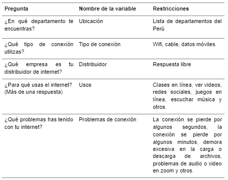

### Variables categóricas ordinales

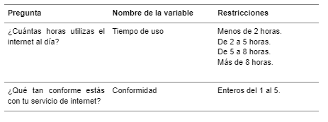

### Variables numéricas continuas

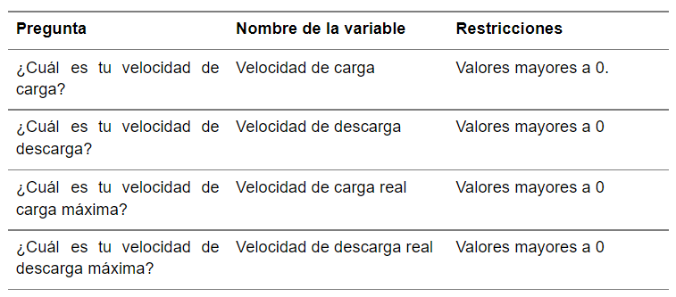

### Variables numéricas discretas

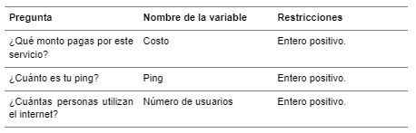

# Plan de realización:

### 1. Recolección de datos

La base de datos, necesaria para lograr los objetivos, se sustentará de una encuesta realizada a la muestra. Para realizar dicha encuesta, se tienen presente las variables que se vinculan directamente con la pregunta de investigación (velocidad, distribuidor, ping, costo,etc.) Asimismo, se debe considerar variables según el contexto en el que se encuentra el estudiante para evaluar cómo éstas influyen en la calidad del servicio que experimenta el usuario (ubicación, número de usuarios, etc).

En la encuesta se hace uso de Speed Test para determinar las velocidades de carga, descarga y el ping que presenta cada estudiante.

### 2. Análisis de la calidad de internet

Un criterio para determinar la calidad de internet se da a través de la obtención de la velocidad mínima de descarga, necesaria para tener una buena conexión. Ésta se calcula mediante la suma de velocidades mínimas por actividades que realiza por el número de personas que usan la red de internet. De este modo, se puede realizar la comparación con la velocidad que se presenta actualmente.

### Tabla de velocidades mínimas por actividad

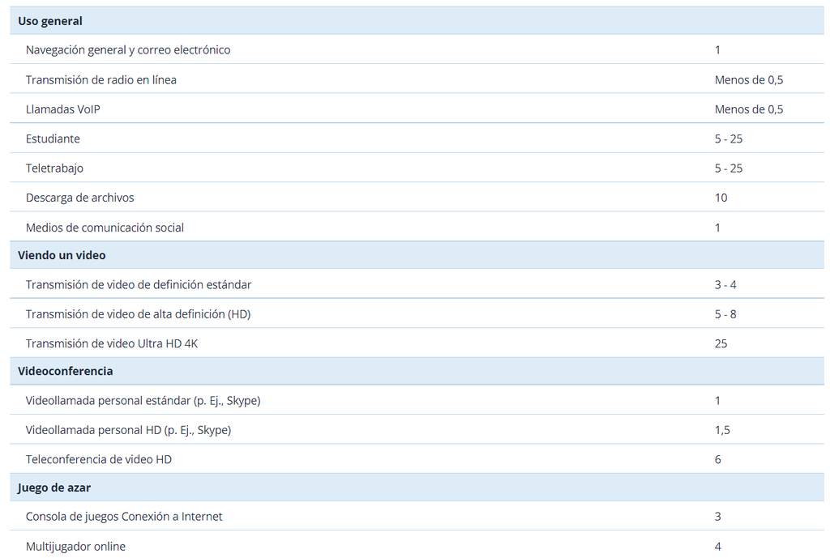

Otro criterio a tener en cuenta es mediante la comparación entre la velocidad de carga y descarga que se presenta con la que ofrece su distribuidor por el monto indicado. Asimismo, así se podrá analizar que tan bueno es el servicio de internet de acuerdo al distribuidor que se presenta.

### Datos

Hasta el momento de la entrega, se cuentan con 153 respuestas, las cuales se muestran a continuación:

[output not shown]

```
## # A tibble: 153 x 15
##    MT           Region Tipo_conexion Distribuidor Costo  Ping V_carga V_descarga
##    <chr>        <chr>  <chr>         <chr>        <dbl> <dbl> <chr>        <dbl>
##  1 28/09/2021 ~ Lima   Wifi          Movistar       150    22 11          196
##  2 28/09/2021 ~ Callao Wifi          Claro          100     9 32.34        97
##  3 28/09/2021 ~ Callao Cable         Movistar        70     5 44.2         50.0
##  4 28/09/2021 ~ Lima   Wifi          Win            120    40 90           90
##  5 28/09/2021 ~ Callao Wifi          Alta veloci~    50    50 4.1          10
##  6 28/09/2021 ~ Lima   Wifi          Cable Vision   105     5 4.72          9.44
##  7 28/09/2021 ~ Cajam~ Datos         Movistar        65    23 0.48          1.02
##  8 28/09/2021 ~ La Li~ Wifi          Claro           80    10 15           25
##  9 28/09/2021 ~ Cajam~ Cable         Movistar       120     5 24.61        26.8
## 10 28/09/2021 ~ Lima   Wifi          Movistar        50    19 5.8          25
## # i 143 more rows
## # i 7 more variables: Tiempo_uso <chr>, Personas <dbl>, Tipo_uso <chr>,
## #   Conformidad <dbl>, Problemas <chr>, VD_ofrecida <dbl>, VC_ofrecida <dbl>
```

# Descriptores numéricos y gráficos

### Velocidad de carga

Se hará uso del promedio, un descriptor numérico necesario para conocer el centro de masa de los datos. Junto al valor de la desviación estándar, para determinar qué tan dispersos son los datos obtenidos. Además, de un descriptor gráfico de tipo histograma para conocer la frecuencia de los datos y poder compararlo con su similar.

Se averiguo el numero de estudiantes de la UTEC, el cual ascendio a 3,475, razón por la cual usamos la formula de estimación con población finita :

$$n =
Z^2(1-alfa/2)*varianza*N/(Z^2*Varianza + error^2*(N-1))$$

donde :

- **n** : Tamaño de la muestra
- **N** : Tamaño de la población
- **alfa** : Nivel de Significancia
- **Z** : Cuantil de la distribución Normal

De aqui en adelante emplearemos esta formula para medias a estimar.

Se desea un nivel de confianza del 95% para la precisión o error con respecto a la estimación del promedio :

Promedio (mbps).

```
## Promedio  :
```

```
## 25.65725
```

```
## Precisión :
```

```
## 8.425777
```

Desviación estándar (mbps)

```
## [1] 54.37793
```

```
##                      fa          fr          fp
## [0;49.9736>         142 0.928104575  92.8104575
## [49.9736;99.9472>     4 0.026143791   2.6143791
## [99.9472;149.9208>    2 0.013071895   1.3071895
## [149.9208;199.8944>   2 0.013071895   1.3071895
## [199.8944;249.868>    2 0.013071895   1.3071895
## [249.868;299.8416>    0 0.000000000   0.0000000
## [299.8416;349.8152>   0 0.000000000   0.0000000
## [349.8152;399.7888>   0 0.000000000   0.0000000
## [399.7888;449.7624>   0 0.000000000   0.0000000
## [449.7624;499.736>    0 0.000000000   0.0000000
## [499.736;550.01>      1 0.006535948   0.6535948
## Total               153 1.000000000 100.0000000
```

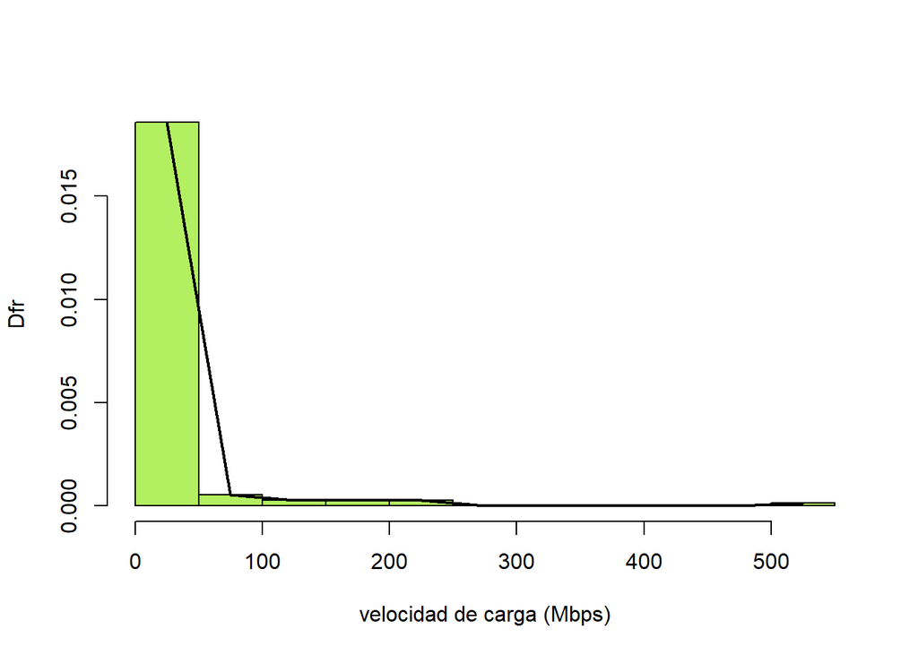

Adicionalmente calcularemos la curtosis y la asimetria formalmente para refrendar lo ya observado en el histograma y adicionaremos un grafico de densidad.

```
## Asimetria  :
```

```
## 6.785909
```

```
## Curtosis    :
```

```
## 56.95645
```

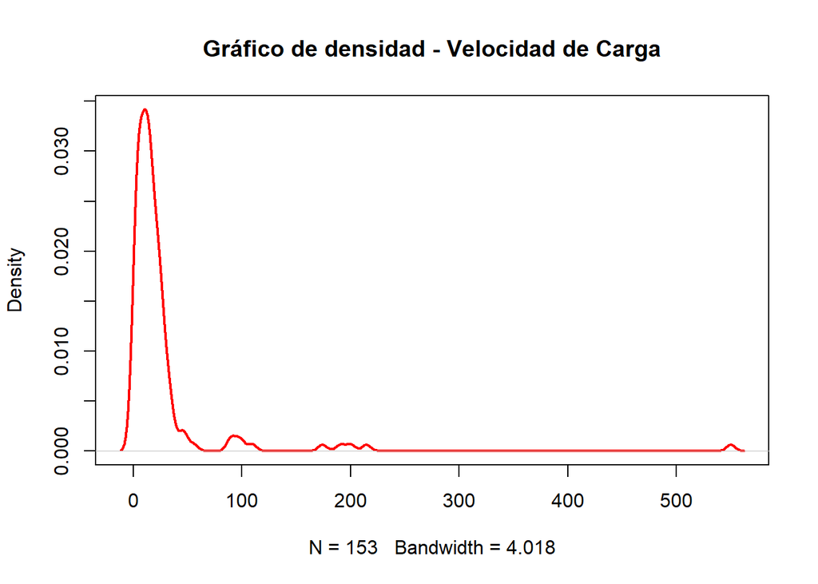

Observamos curtosis de 56 mucho mayor a 3, sabemos que la distribución normal estandar tiene una curtosis de 3, en este caso la distribución de datos de **Velocidad de Carga**, presentan un modelamiento leptocurtico, es decir una curva con campana mucho más elevada que la presentada por una distribución normal estandar, lo cual nos indica mayor concentración de los datos respecto a su promedio que la presentada por la distribución normal estandar.

También los datos presentan un comportamiento unimodal y una asimetria positiva, lo cual implica que los datos se concentran en los valores bajos de la variable en cuestión.

### Velocidad de descarga

Se hará uso de un descriptor numérico del tipo promedio para conocer el centro de masa de los datos. Junto al valor de la desviación estándar, se puede saber la velocidad de carga de un alumno. Además, de un descriptor gráfico de tipo histograma para conocer la frecuencia de los datos y poder compararlo con su similar.

Promedio (mbps).

```
## Promedio  :
```

```
## 53.25255
```

```
## Precisión :
```

```
## 10.26852
```

Desviación estándar (mbps)

```
## [1] 66.27056
```

```
##                      fa          fr          fp
## [0;49.9273>         106 0.692810458  69.2810458
## [49.9273;99.8546>    26 0.169934641  16.9934641
## [99.8546;149.7819>   11 0.071895425   7.1895425
## [149.7819;199.7092>   4 0.026143791   2.6143791
## [199.7092;249.6365>   3 0.019607843   1.9607843
## [249.6365;299.5638>   1 0.006535948   0.6535948
## [299.5638;349.4911>   1 0.006535948   0.6535948
## [349.4911;399.4184>   0 0.000000000   0.0000000
## [399.4184;449.3457>   0 0.000000000   0.0000000
## [449.3457;499.273>    0 0.000000000   0.0000000
## [499.273;550.01>      1 0.006535948   0.6535948
## Total               153 1.000000000 100.0000000
```

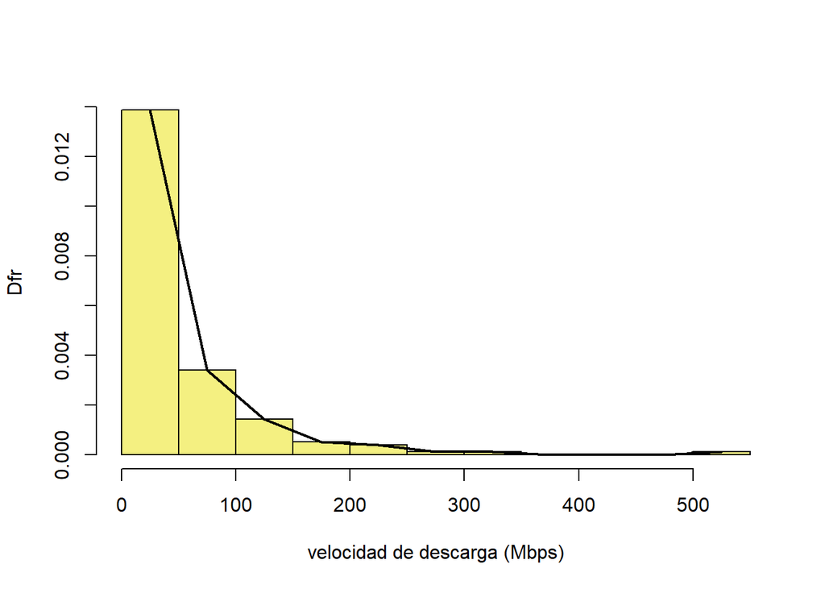

Adicionalmente calcularemos la curtosis y la asimetria formalmente para refrendar lo ya observado en el histograma y adicionaremos un grafico de densidad.

```
## Asimetria   :
```

```
## 3.887073
```

```
## Curtosis    :
```

```
## 21.67954
```

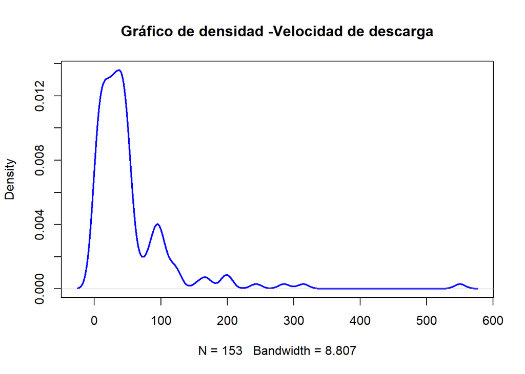

Observamos curtosis de 21 mucho mayor a 3, sabemos que la distribución normal estandar tiene una curtosis de 3, en este caso la distribución de datos de **Velocidad de Descarga**, presentan un modelamiento leptocurtico, es decir una curva con campana mucho más elevada que la presentada por una distribución normal estandar, lo cual nos indica mayor concentración de los datos respecto a su promedio que la presentada por la distribución normal estandar.

### Ping

Para esta variable consideramos utilizar el descriptor numérico de la mediana, ya que los valores suelen ser muy extremos y por ello pueden afectar el promedio en caso se use ello. En el caso de descriptores gráficos se usará un boxplot para tener en cuenta la representación de los datos evitando los extremos. De esta forma podremos evidenciar la asimetría en el los resultados. Además, la variable es un factor que ayudará a determinar los problemas de los estudiantes, ya que el retraso puede asociarse a la calidad que están obteniendo.

Cabe resaltar que el cálculo de la precisión, se aplica solo a la media y a las proporciones, no se aplica para medidas de posición como la mediana que es el segundo cuartil.

Mediana:

```
## [1] 12
```

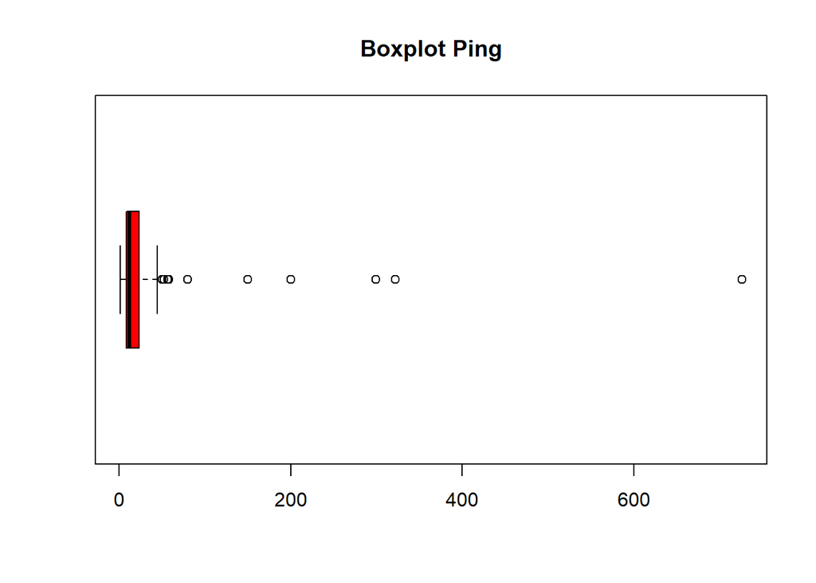

Adicionalmente calcularemos la curtosis y la asimetria formalmente para refrendar lo ya observado en el boxplot y adicionaremos un grafico de densidad.

```
## Asimetria   :
```

```
## 7.667237
```

```
## Curtosis    :
```

```
## 67.81622
```

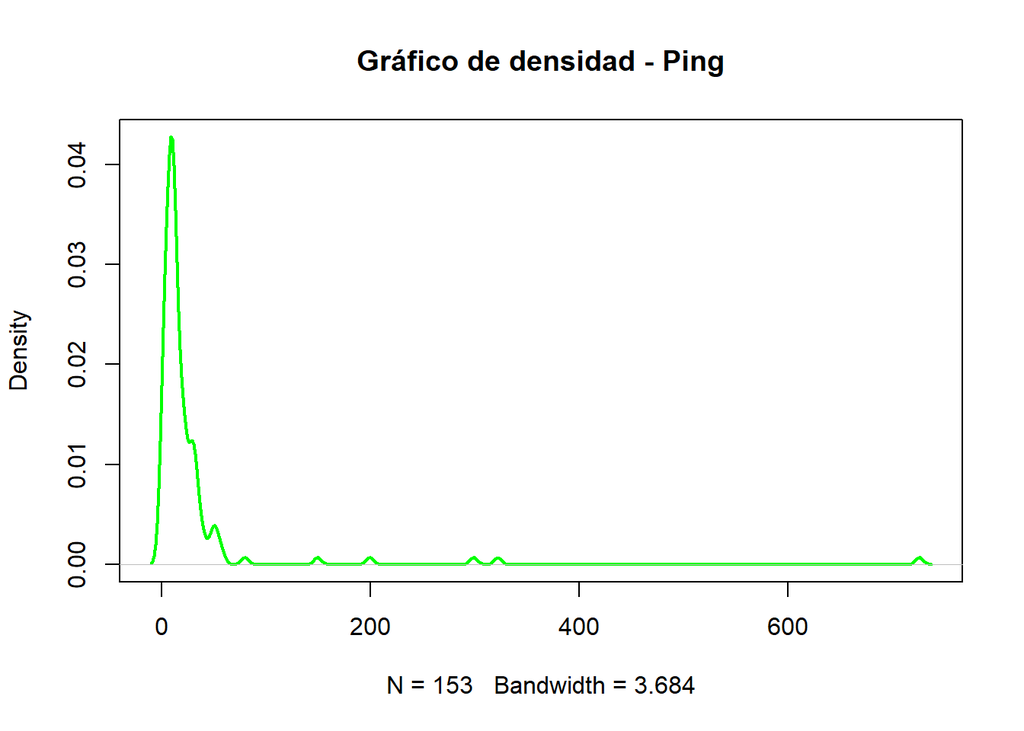

Observamos curtosis de 67 mucho mayor a 3, sabemos que la distribución normal estandar tiene una curtosis de 3, en este caso la distribución de datos de **Ping**, presentan un modelamiento leptocurtico, es decir una curva con campana mucho más elevada que la presentada por una distribución normal estandar, lo cual nos indica mayor concentración de los datos respecto a su promedio que la presentada por la distribución normal estandar.

También los datos presentan un comportamiento unimodal y una asimetria positiva, lo cual implica que los datos se concentran en los valores bajos de la variable en cuestión.

### Costo

Se desea un nivel de confianza del 95% para la precisión o error con respecto a la estimación del promedio :

Promedio:

```
## Promedio  :
```

```
## 105.0633
```

```
## Precisión :
```

```
## 9.443203
```

Desviación estándar:

```
## [1] 60.94415
```

```
##                        fa          fr          fp
## [0;29.00000>            1 0.006535948   0.6535948
## [29.00;71.81818>       46 0.300653595  30.0653595
## [71.81818;114.63636>   56 0.366013072  36.6013072
## [114.63636;157.45455>  38 0.248366013  24.8366013
## [157.45455;200.27273>   7 0.045751634   4.5751634
## [200.27273;243.09091>   0 0.000000000   0.0000000
## [243.09091;285.90909>   1 0.006535948   0.6535948
## [285.90909;328.72727>   2 0.013071895   1.3071895
## [328.72727;371.54545>   0 0.000000000   0.0000000
## [371.54545;414.36364>   0 0.000000000   0.0000000
## [414.36364;457.18182>   1 0.006535948   0.6535948
## [457.18182;500.00>      1 0.006535948   0.6535948
## Total                 153 1.000000000 100.0000000
```

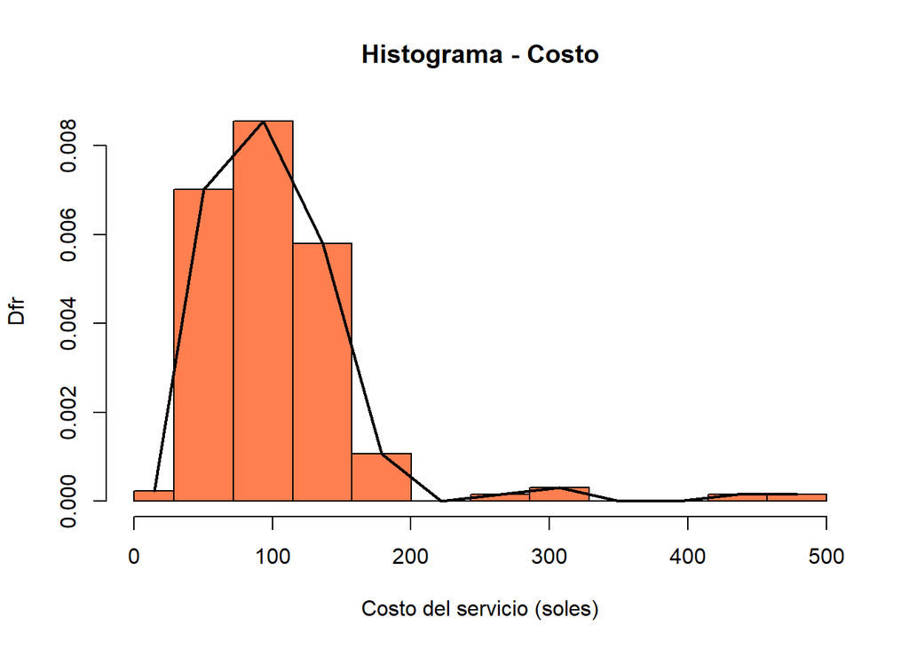

Adicionalmente calcularemos la curtosis y la asimetria formalmente para refrendar lo ya observado en el histograma y adicionaremos un grafico de densidad.

```
## Asimetria   :
```

```
## 3.489191
```

```
## Curtosis    :
```

```
## 17.33303
```

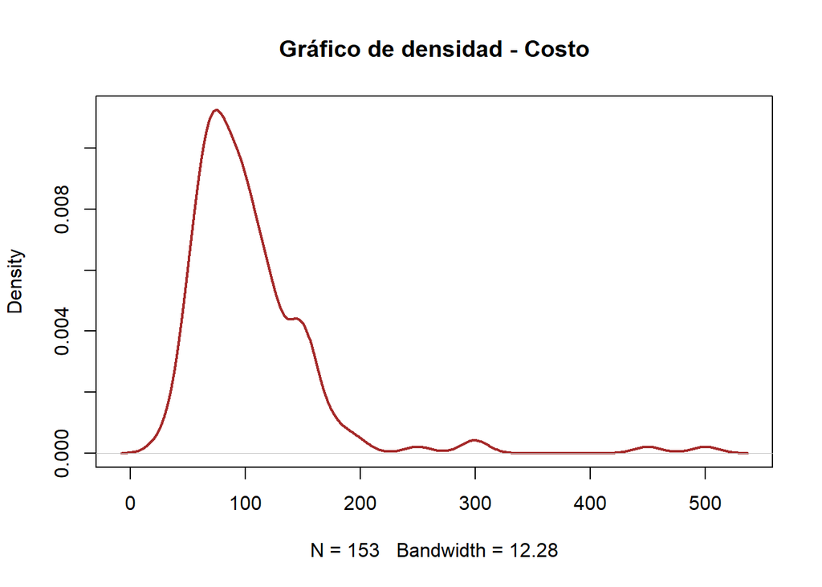

Observamos curtosis de 17 mayor a 3, sabemos que la distribución normal estandar tiene una curtosis de 3, en este caso la distribución de datos de **Costo**, presentan un modelamiento leptocurtico, es decir una curva con campana mucho más elevada que la presentada por una distribución normal estandar, lo cual nos indica mayor concentración de los datos respecto a su promedio que la presentada por la distribución normal estandar.

También los datos presentan un comportamiento unimodal y una asimetria positiva, lo cual implica que los datos se concentran en los valores bajos de la variable en cuestión.

### Número de usuarios

Cabe resaltar que el cálculo de la precisión, se aplica solo a la media y a las proporciones, no se aplica para medidas de posición como la mediana que es el segundo cuartil.

Mediana:

```
## [1] 4
```

```
##             Fabs       Frel       Fpor
## 1 usuario      9 0.05882353   5.882353
## 2 usuarios    20 0.13071895  13.071895
## 3 usuarios    35 0.22875817  22.875817
## 4 usuarios    40 0.26143791  26.143791
## 5 usuarios    29 0.18954248  18.954248
## 6 usuarios     9 0.05882353   5.882353
## +6 usuarios   11 0.07189542   7.189542
## Total        153 1.00000000 100.000000
```

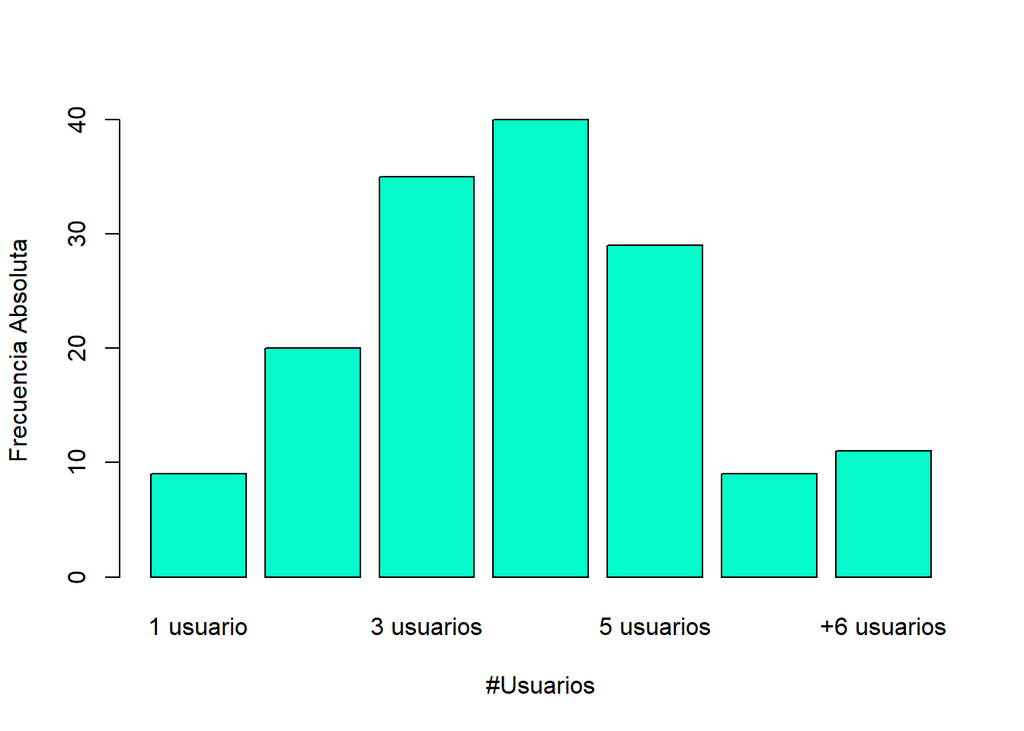

### Conformidad

Para este caso se utilizará la gráfica barras para conocer la proporción de estudiantes conformes con su servicio a internet. Además, se podrá combinar con otros elementos para obtener la conformidad en un factor. En este caso al enumerar las variables es conveniente usar la mediana por si hay acumulación en los extremos de los datos y con el gráfico de barras corroborar este hecho.

Cabe resaltar que el cálculo de la precisión, se aplica solo a la media y a las proporciones, no se aplica para medidas de posición como la mediana que es el segundo cuartil.

Mediana:

```
## [1] 3
```

```
##       Fabs       Frel       Fpor
## 1        6 0.03921569   3.921569
## 2       16 0.10457516  10.457516
## 3       60 0.39215686  39.215686
## 4       54 0.35294118  35.294118
## 5       17 0.11111111  11.111111
## Total  153 1.00000000 100.000000
```

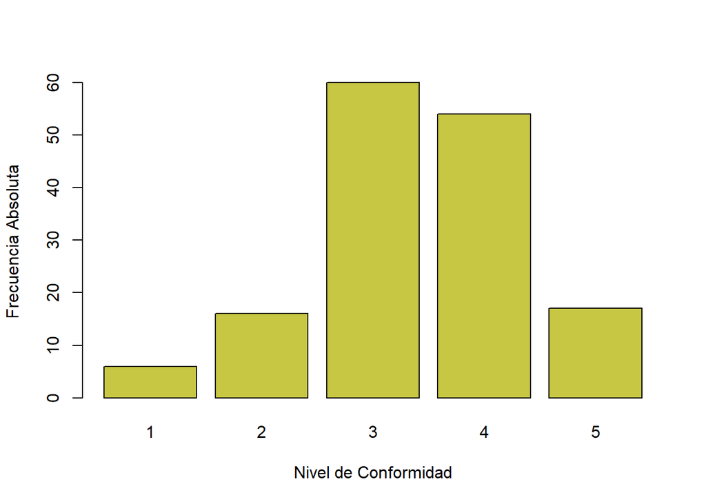

### Distribuidora

```
##          Fabs       Frel       Fpor
## Claro      48 0.31372549  31.372549
## Movistar   70 0.45751634  45.751634
## Win         5 0.03267974   3.267974
## Entel       4 0.02614379   2.614379
## Otros      26 0.16993464  16.993464
## Total     153 1.00000000 100.000000
```

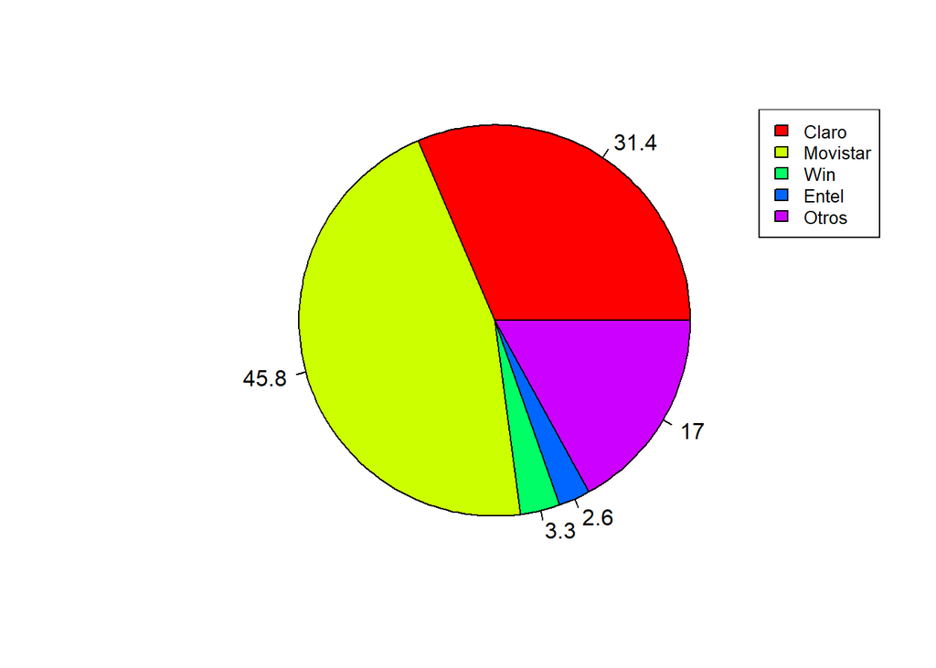

### Ubicación

Para este factor se utilizará el gráfico de barras para conocer de forma precisa la cantidad de alumnos ubicados en las regiones del Perú. Además, podremos usar ello para compararla con otras variables y conocer la calidad del servicio por regiones. Para este dato buscamos la precisión, por lo que, usamos las barras. No usaremos la moda, ya que para nuestro cálculo es mejor analizar las regiones como tales.

```
##             Fabs       Frel       Fpor
## Amazonas       7 0.04575163   4.575163
## Cajamarca      8 0.05228758   5.228758
## Callao         8 0.05228758   5.228758
## La Libertad    6 0.03921569   3.921569
## Lima          97 0.63398693  63.398693
## Otros         27 0.17647059  17.647059
## Total        153 1.00000000 100.000000
```

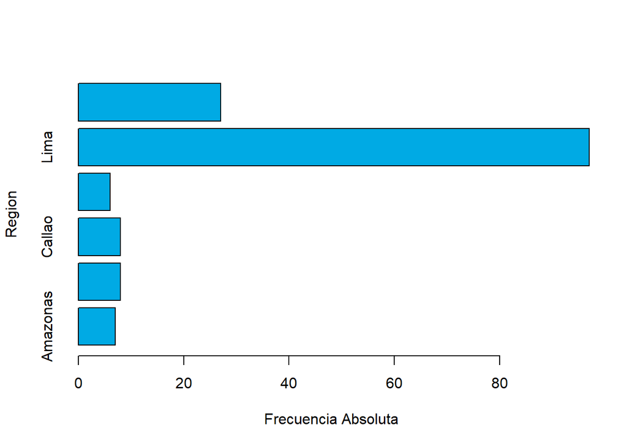

### Tipo de uso

Con esta variable usaremos la gráfica de barras para comparar los usos que le dan usualmente los alumnos a su internet. De esta forma, podremos estimar la cantidad de internet que se necesita con los datos de la tabla de consumo presentada al inicio.

```
##         fa         fr         fp
## Clases 153 0.22238372  22.238372
## videos 133 0.19331395  19.331395
## Redes  131 0.19040698  19.040698
## Juegos  97 0.14098837  14.098837
## música 136 0.19767442  19.767442
## Otros   38 0.05523256   5.523256
## Total  688 1.00000000 100.000000
```

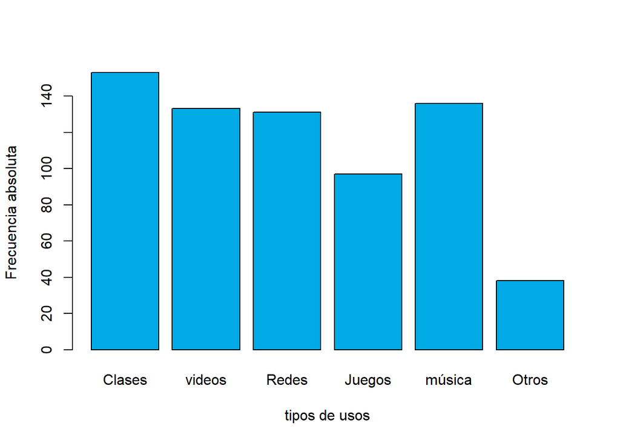

### Velocidad de carga máxima

Para esta variable se hará uso del promedio para conocer el centro de masa de los datos. Junto al valor de la desviación estándar, para determinar qué tan dispersos son los datos obtenidos. Además, del descriptor gráfico histograma para conocer la frecuencia de los datos.

Se desea un nivel de confianza del 95% para la precisión o error con respecto a la estimación del promedio :

Promedio (mbps)

```
## Promedio  :
```

```
## 37.11176
```

```
## Precisión :
```

```
## 9.263211
```

Desviación estándar (mbps)

```
## [1] 59.78253
```

```
##                        fa          fr          fp
## [0;4.1>                 1 0.006535948   0.6535948
## [4.1;53.72727>        141 0.921568627  92.1568627
## [53.72727;103.35455>    4 0.026143791   2.6143791
## [103.35455;152.98182>   0 0.000000000   0.0000000
## [152.98182;202.60909>   2 0.013071895   1.3071895
## [202.60909;252.23636>   4 0.026143791   2.6143791
## [252.23636;301.86364>   0 0.000000000   0.0000000
## [301.86364;351.49091>   0 0.000000000   0.0000000
## [351.49091;401.11818>   0 0.000000000   0.0000000
## [401.11818;450.74545>   0 0.000000000   0.0000000
## [450.74545;500.37273>   0 0.000000000   0.0000000
## [500.37273;550]         1 0.006535948   0.6535948
## Total                 153 1.000000000 100.0000000
```

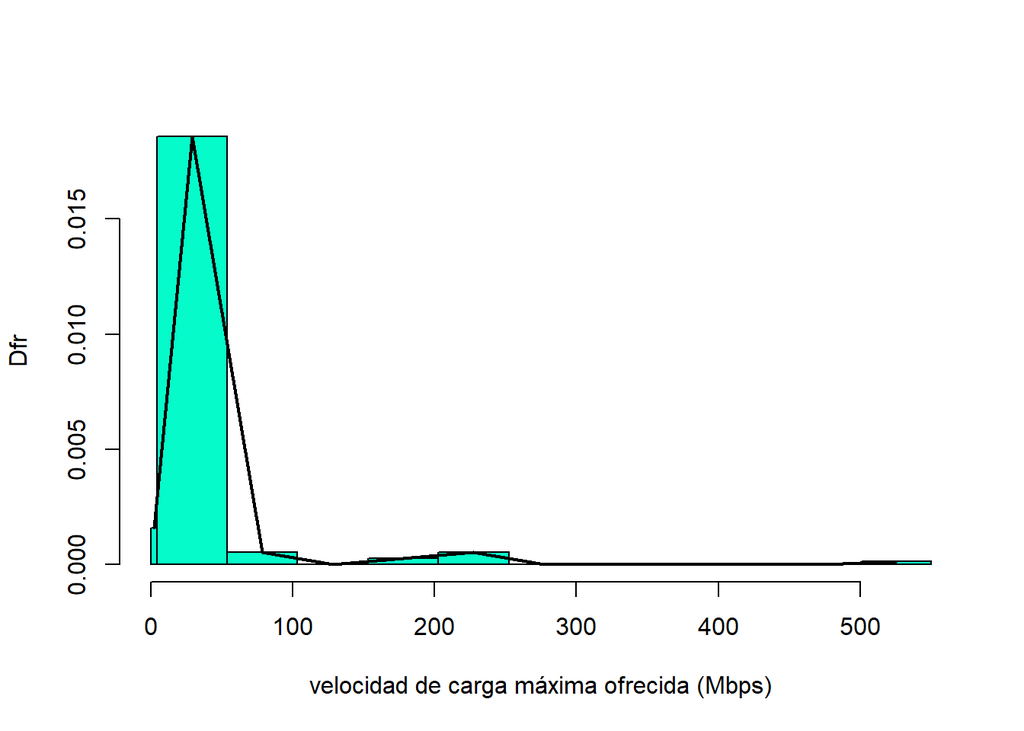

Adicionalmente calcularemos la curtosis y la asimetria formalmente para refrendar lo ya observado en el histograma y adicionaremos un grafico de densidad.

```
## Asimetria   :
```

```
## 5.559732
```

```
## Curtosis    :
```

```
## 37.71821
```

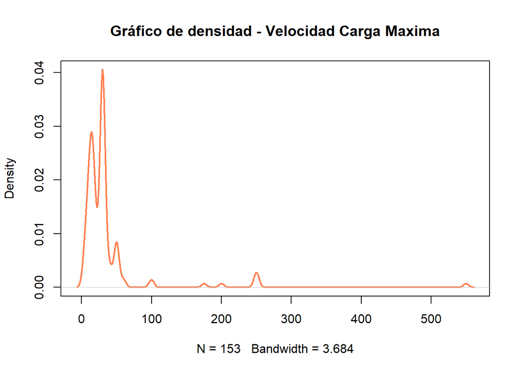

### Velocidad de descarga máxima

Se hará uso del promedio, junto al valor de la desviación estándar, para determinar qué tan dispersos son los datos obtenidos; y del histograma, un descriptor gráfico necesario para conocer la frecuencia de los datos.

Se desea un nivel de confianza del 95% para la precisión o error con respecto a la estimación del promedio :

Promedio (mbps)

```
## Promedio  :
```

```
## 96.20902
```

```
## Precisión :
```

```
## 13.05709
```

Desviación estándar (mbps)

```
## [1] 84.2673
```

```
##                        fa          fr          fp
## [0;10>                  8 0.052287582   5.2287582
## [10;59.09091>          56 0.366013072  36.6013072
## [59.09091;108.18182>   53 0.346405229  34.6405229
## [108.18182;157.27273>  18 0.117647059  11.7647059
## [157.27273;206.36364>  12 0.078431373   7.8431373
## [206.36364;255.45455>   1 0.006535948   0.6535948
## [255.45455;304.54545>   1 0.006535948   0.6535948
## [304.54545;353.63636>   0 0.000000000   0.0000000
## [353.63636;402.72727>   1 0.006535948   0.6535948
## [402.72727;451.81818>   0 0.000000000   0.0000000
## [451.81818;500.90909>   2 0.013071895   1.3071895
## [500.90909; 550]        1 0.006535948   0.6535948
## Total                 153 1.000000000 100.0000000
```

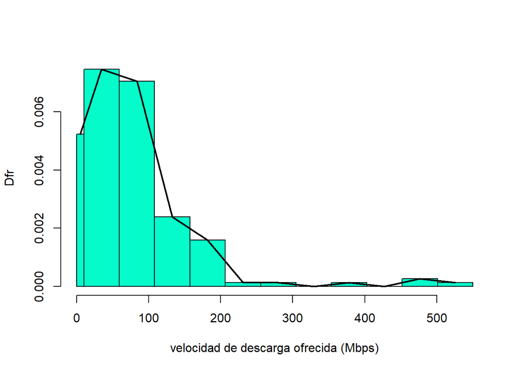

Adicionalmente calcularemos la curtosis y la asimetria formalmente para refrendar lo ya observado en el histograma y adicionaremos un grafico de densidad.

```
## Asimetria   :
```

```
## 2.896167
```

```
## Curtosis    :
```

```
## 11.28503
```

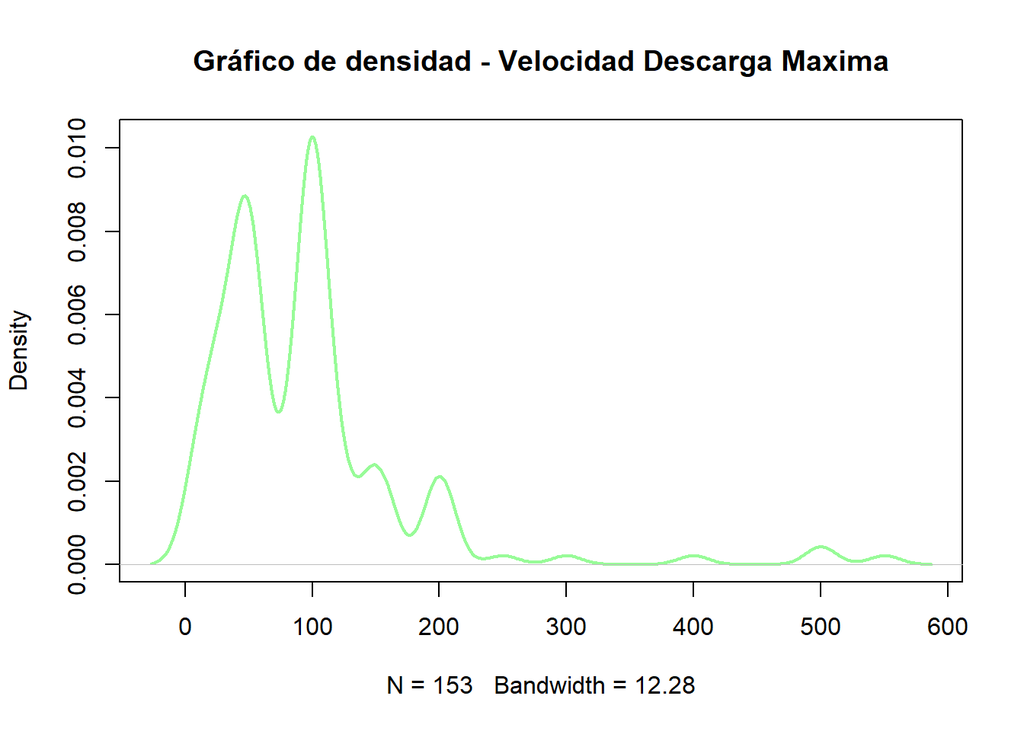

Observamos curtosis de 11 mayor a 3, sabemos que la distribución normal estandar tiene una curtosis de 3, en este caso la distribución de datos de **Velocidad Descarga Maxima**, presentan un modelamiento leptocurtico, es decir una curva con campana mucho más elevada que la presentada por una distribución normal estandar, lo cual nos indica mayor concentración de los datos respecto a su promedio que la presentada por la distribución normal estandar.

También los datos aunque podian acercarse a ser bimodales, presentan un comportamiento unimodal y una asimetria positiva, lo cual implica que los datos se concentran en los valores bajos de la variable en cuestión.

# Relación entre variables y Patrones observados

### Velocidad de descarga máxima ofrecida y velocidad de descarga real

Presentamos esta gráfica donde usamos la función y=x para verificar la pérdida o ganancia de acuerdo a la situación del alumno. Sin embargo, añadiendo otra función podemos verificar si se cumplen las normas. Esta relación con la ayuda de una recta y = 2.5x (por la obligación de las empresas a brindar esta cantidad de internet por el que se paga que es el 0.4 de la real) a evidenciar si la concentración de puntos se encuentra a cierto lado de la linea indicando si están concentrados en la izquierda un incumplimiento por parte de la compañía, ya que la velocidad obtenida es menor a la asegurada y al lado de la derecha el cumplimiento del acuerdo, ya que la velocidad obtenida es mayor a la mínima asegurada.

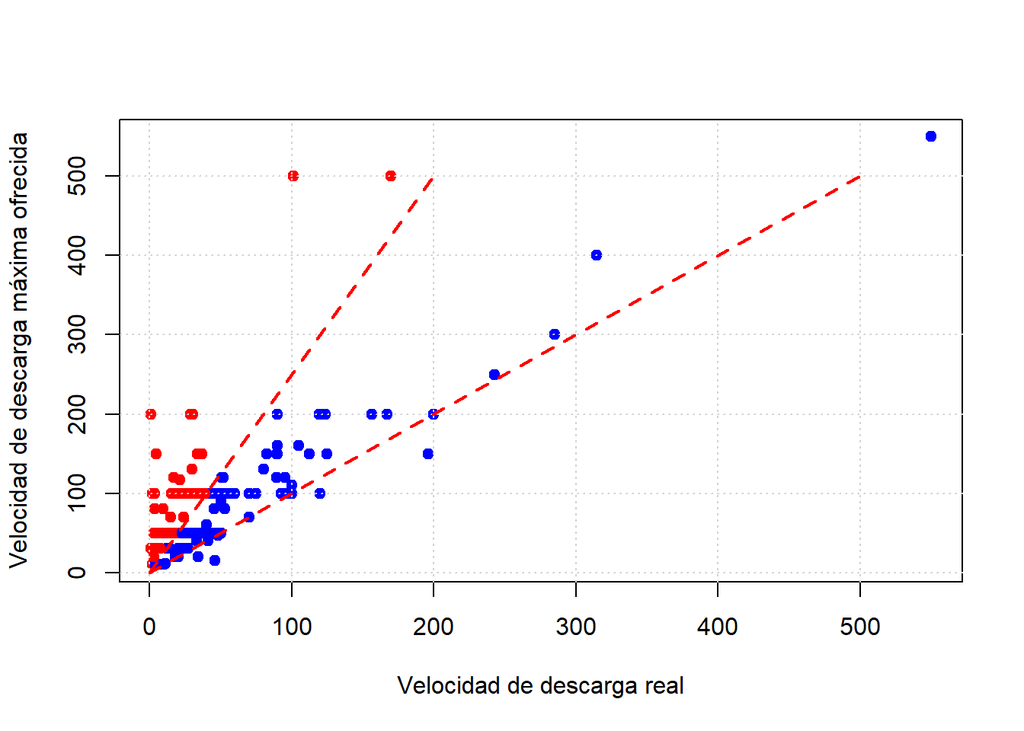

```
## colores
## blue  red
##  100   53
```

### Velocidad de carga máxima ofrecida y velocidad de carga real

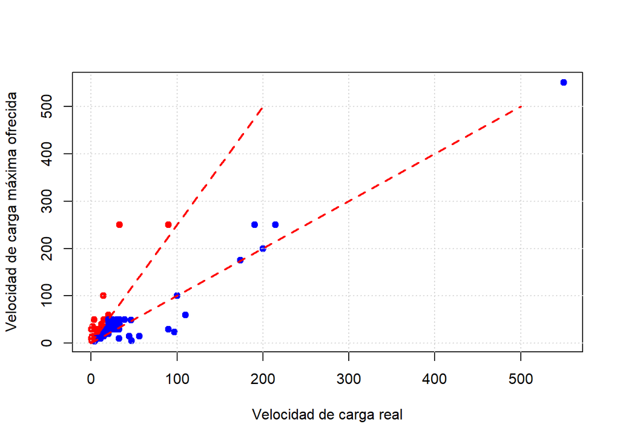

```
## colores
## blue  red
##  111   42
```

### Número de personas que usan internet y nivel de conformidad

Podemos apreciar esta relación por gráfico de Mosaic plot donde el color representa el nivel de conformidad dependiendo del número de personas que usan internet. Además, el ancho de las barras representa la cantidad de personas que tienen tal cantidad de personas usando internet. Con ello, está gráfica nos ayuda a entender a qué número de personas que utilizan el internet con el alumno este se encuentra más satisfecho teniendo más peso las barras más anchas para deducir el número más adecuado.

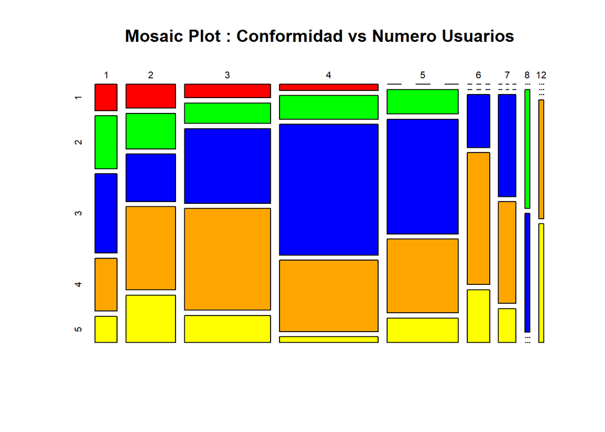

**Patrones observados:**

- Se observa que la mayoría de los estudiantes con un nivel de conformidad de 3 y 4, emplean una conexión utilizada por 3,4 y 5 usuarios.

### Tipo de conexión y Conformidad

De estos datos podremos obtener la relación al interceptar estas variables de la cantidad de personas que están en cierto grado conformes con su servicio y el tipo de conexión que usa este grupo. Para ello, usaremos la gráfica de barras apiladas y comparar los tipos de conexiones en los distintos grados de conformidad. Esta relación nos brindará información para recomendar a los alumnos el tipo de conexión deberían usar en base a la experiencia de sus compañeros.

```
##
##                  1          2          3          4          5
##   Cable 0.16666667 0.25000000 0.26666667 0.33333333 0.47058824
##   Datos 0.00000000 0.25000000 0.01666667 0.01851852 0.00000000
##   Wifi  0.83333333 0.50000000 0.71666667 0.64814815 0.52941176
```

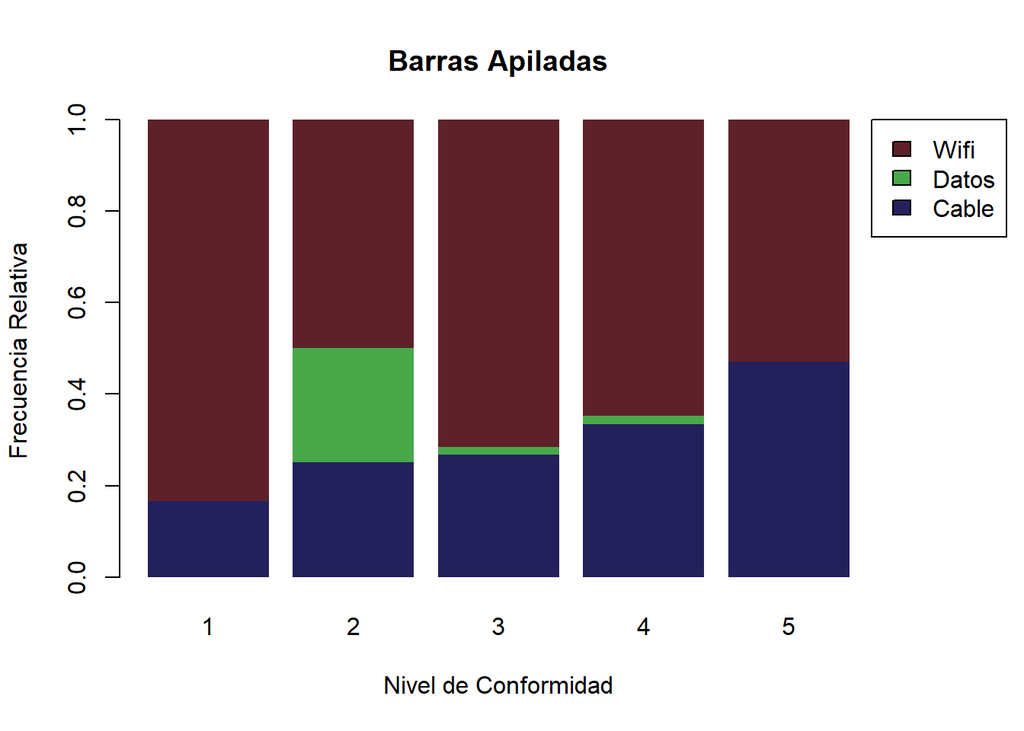

**Patrones observados:**

- Se observa que el nivel de conformidad m?s bajo tiene mayor porcentaje de usuarios de WIFI.
- Se observa que la frecuencia relativa de los usuarios de cable aumenta con el nivel de conformidad.

# Validación de dependencia entre variables (regresión lineal)

Se selecciona, de todos los gráficos de dispersión, cuatro de ellos. Usando dos criterios:

- Que muestre, de manera visual, una potencial relación lineal.
- Que ambas variables tengan una relación lógica y coherente.

Los cuatro gráficos que han sido seleccionados son:

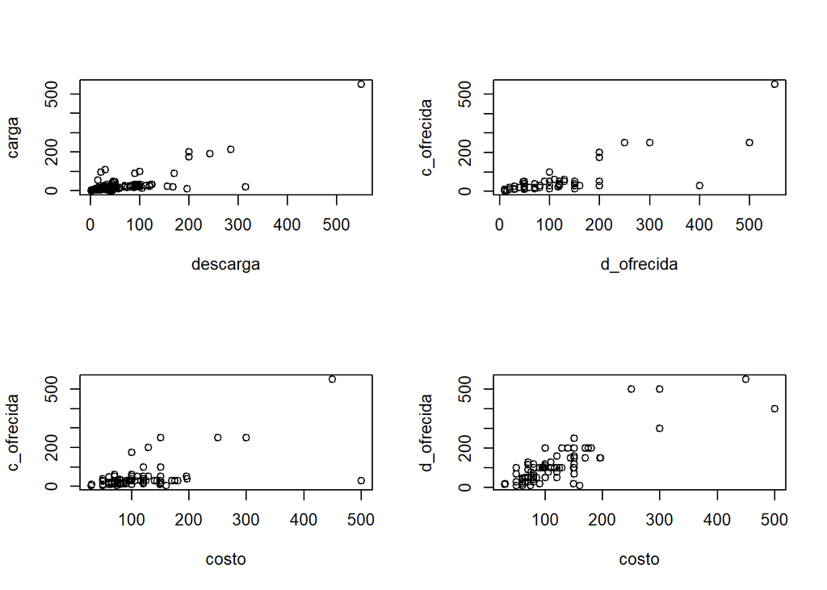

Para la validación de las relaciones entre variables con regresión lineal mediante hipótesis:

Se sabe que la ecuación de la recta es

$y = \text{pendiente}\cdot x + \text{intersección}$

Se definen la siguiente prueba de hipótesis:

- $H_0$:

  La pendiente es igual a 0 (no existe una relación de dependencia lineal entre las dos variables planteadas
- $H_1$:

  Hipótesis alterna: La pendiente es distinta de 0 (existe una relación de dependencia lineal entre las dos variables planteadas)

Ya que se harán 4 análisis, se han creado una serie de funciones que serán usadas para hallar los principales valores numéricos que ayudarán a validar o rechazar las hipótesis planteadas.

```r
# Funciones a usar:
RegreLin <- function(x,y){
  xprom <- sum(x)/length(x)
  yprom <- sum(y)/length(y)
  pendiente <- sum((x-xprom)*(y-yprom))/sum((x-xprom)^2)
  interseccion <- yprom-pendiente*xprom
  lista <- c(pendiente,interseccion,yprom)
  return(lista)
}
FunLineal <- function(x,pendiente,interseccion){
  y <- x*pendiente+interseccion
  return(y)
}
SumCuadrad <- function(y,yaproximado,ypromedio){
  SCTotal <- sum((y-ypromedio)^2)
  SCError <- sum((y-yaproximado)^2)
  SCRegre <- sum((yaproximado-ypromedio)^2)
  SC <- c(SCTotal,SCError,SCRegre)
  return(SC)
}
EstadF <- function(x,SC,k){
  RCM <- SC[3]/k #RCM: Regresión Media Cuadrada
  ECM <- SC[2]/(length(x)-k-1) #ECM: Error Medio Cuadrado o Varianza del error (su raíz cuadrada es la desviación estándar del error)
  estadisticoF <- RCM/ECM
  return(estadisticoF)
}
RelacionLineal <- function(x,y,k,significancia){
  lista <- RegreLin(x,y)
  yaprox <- FunLineal(x,lista[1],lista[2])
  SC <- SumCuadrad(y,yaprox,lista[3])
  r <- sqrt(SC[3]/SC[1])
  Fcalcul <- EstadF(x,SC,k)
  pvalor <- pf(Fcalcul,k,length(x)-k-1,lower.tail = F)
  EFES <- c(pvalor,lista[1],lista[2],r)
  return(EFES)
}
```

Correspondientemente, la función RelaciónLineal es la que reúne las funciones anteriores y es la que devolverá los valores de:

- Pendiente de la recta
- Intersección con el eje Y
- Significancia
- p - valor
- Coeficiente de determinación (r)

Valores que determinan:

- Si $r \approx 0$, se acepta la hipótesis nula. Si $r \approx 1$, entonces se rechaza la hipótesis nula y se acepta la hipótesis alterna. (Se evaluarán valores de $r$ mayores a 0.7)
- Si el estadístico $Significancia<p-\text{valor}$, no se rechazará la hipótesis nula. De lo contrario, se rechazará la hipótesis nula.

Aunque se recomienda sólo hacer uso del valor-p y la significancia para validar o rechazar la hipótesis nula, para este proyecto, se tendrán en cuenta ambos valores (coeficiente de determinación y el valor-p). Así, el grupo se asegura de llegar a conclusiones más sólidas.

### Velocidad descarga máxima vs Costo

[figure not shown]

[figure not shown]

```
## Pendiente: 1.175632
```

```
## Intersección: -27.30682
```

```
## coeficiente de determinación: 0.7229176
```

```
## Coeficiente de correlación: 0.8502456
```

```
## valor-p: 6.281797e-44
```

```
## Significancia: 0.05
```

**Predicciones:**

Después de hacer uso de las funciones, los resultados numéricos arrojan un coeficiente de determinación (r) mayor a 0.7 y ligeramente cercano a 1, además, el valor-p es menor a la significancia de valor 0.05.Se observa también en el gráfico que la gran mayoría de los puntos (observaciones) obedecen a la función lineal (rojo).Finalmente, para ésta relación, se rechazará la hipótesis nula y se aceptará la alternativa.

### Velocidad carga máxima vs Velocidad descarga máxima

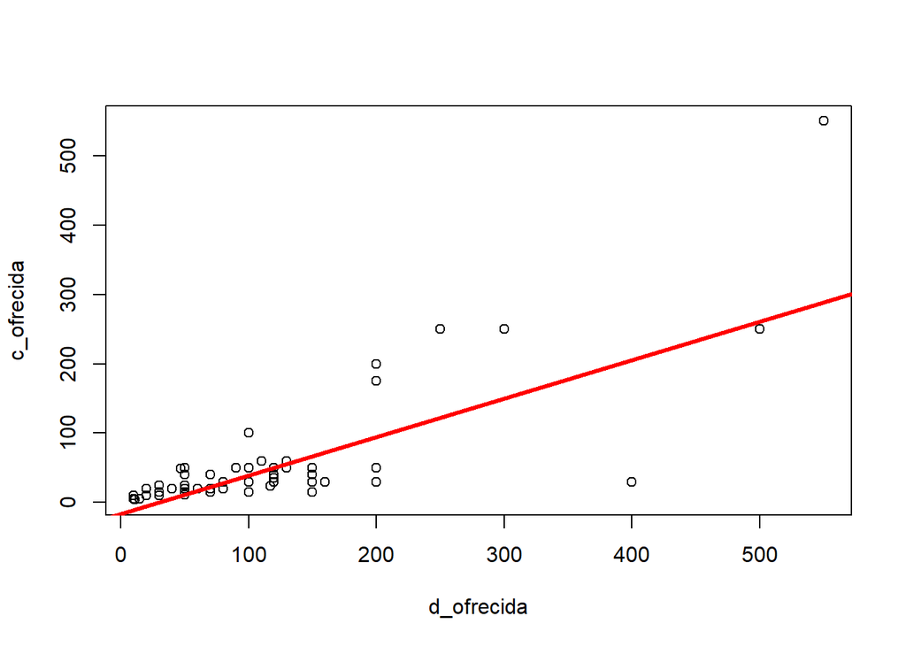

```
## Pendiente: 0.5544979
```

```
## Intersección: -16.23593
```

```
## coeficiente de determinación: 0.610899
```

```
## Coeficiente de correlación: 0.7816003
```

```
## valor-p: 9.26111e-33
```

```
## Significancia: 0.05
```

Se muestra un valor-p mucho menor a la significancia. Mientras tanto, a pesar de que el coeficiente de determinación está más cercano al 1 que al 0, no supera al 0.7 recomendado. En la gráfica se observa que la recta tiene muchas observaciones acumuladas cerca al origen de esta misma. Por ello, se ha decidido aceptar la hipótesis nula.

### Velocidad carga - Velocidad descarga

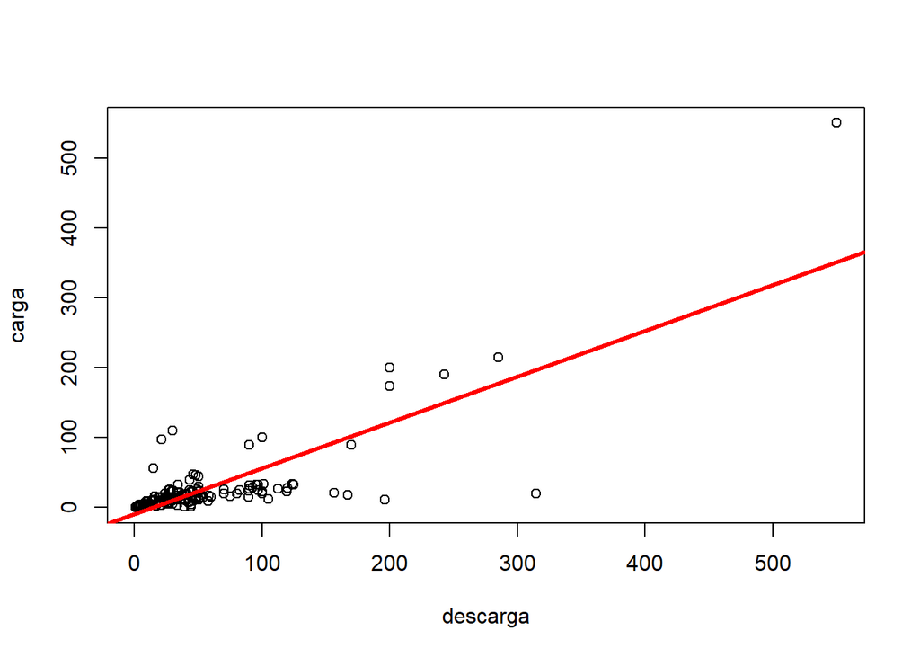

```
## Pendiente: 0.654386
```

```
## Intersección: -9.190468
```

```
## coeficiente de determinación: 0.63601
```

```
## Coeficiente de correlación: 0.7975024
```

```
## valor-p: 5.897139e-35
```

```
## Significancia: 0.05
```

**Predicciones:**

Al igual que la anterior relación, se observa un valor-p menor a la significancia, sin embargo, presenta un coeficiente de determinación menor a 0.7. Por lo cual se acepta la hipótesis nula.